# Introduction to collocation functions in the quanteda.extras R package

David Brown

## Load the quanteda.extras package

Load the package, as well as others that we’ll use in this vignette.

```r
library(quanteda.extras)
library(quanteda)
library(tidyverse)
library(ggraph)
```

## Prepare the data

First, we’ll use to **preprocess_text( )** function to “clean” the text data. See the **preprocess vignette** for more information.

```r
sc <- sample_corpus %>%
  mutate(text = preprocess_text(text))
```

Next, create a corpus and tokenize the data:

```r
sc_tokens <- sc %>%
  corpus() %>% # create a corpus object
  tokens(what="fastestword", remove_numbers=TRUE) # tokenize the data
```

## Collocates by mutual information

The **collocates_by_MI( )** function produces collocation measures (by pointwise mutual information) for a specified token in a **quanteda tokens** object. In addition to a token, a span or window (as given by a number of words to the **left** and **right** of the **node word**) is required. The default is 5 to the left and 5 to the right.

We’ll start by making a table of tokens that collocate with the token *money*.

```r
money_collocations <- collocates_by_MI(sc_tokens, "money")
```

Check the result:

| token | col_freq | total_freq | MI_1 |
| --- | --- | --- | --- |
| 10:29 | 1 | 1 | 11.08049 |
| 38th | 1 | 1 | 11.08049 |
| allocations | 1 | 1 | 11.08049 |
| americanizing | 1 | 1 | 11.08049 |
| anthedon | 1 | 1 | 11.08049 |
| assignats | 1 | 1 | 11.08049 |

Now, let’s make a similar table for collocates of *time*.

```r
time_collocations <- collocates_by_MI(sc_tokens, "time")
```

| token | col_freq | total_freq | MI_1 |
| --- | --- | --- | --- |
| decleat | 2 | 1 | 10.135473 |
| poignantly | 2 | 1 | 10.135473 |
| 16a | 1 | 1 | 9.135473 |
| 17a | 1 | 1 | 9.135473 |
| 21h | 1 | 1 | 9.135473 |
| aba | 1 | 1 | 9.135473 |

As is clear from the above table, MI is sensitive to rare/infrequent words. Because of that sensitivity, it commmon to make thresholds for both token frequency (absolute frequency) and MI score (ususally at some value ≥ 3).

For our purposes, we’ll filter for AF ≥ 5 and MI ≥ 5.

```r
tc <- time_collocations %>% filter(col_freq >= 5 & MI_1 >= 5)
mc <- money_collocations %>% filter(col_freq >= 5 & MI_1 >= 5)
```

Check the result:

| token | col_freq | total_freq | MI_1 |
| --- | --- | --- | --- |
| warner | 6 | 8 | 8.720436 |
| cessation | 5 | 7 | 8.650046 |
| irradiation | 5 | 7 | 8.650046 |
| lag | 5 | 7 | 8.650046 |
| wasting | 7 | 11 | 8.483396 |
| frame | 7 | 16 | 7.942828 |

| token | col_freq | total_freq | MI_1 |
| --- | --- | --- | --- |
| owe | 5 | 21 | 9.010102 |
| raise | 10 | 79 | 8.098639 |
| extra | 6 | 64 | 7.665454 |
| spend | 10 | 111 | 7.608004 |
| insurance | 5 | 64 | 7.402420 |
| spent | 9 | 122 | 7.319679 |

## Create a tbl_graph object for plotting

A [**tbl_graph**](https://www.data-imaginist.com/2017/introducing-tidygraph/) is a data structure for **tidyvers** (ggplot2) network plotting.

For this, we’ll use the **col_network( )** function.

```r
net <- col_network(tc, mc)
```

## Plot network

The network plot shows the tokens that distinctly collocate with either *time* or *money*, as well as those that interect. The distance from the central tokens (*time* and *money*) is governed by the MI score and the transparency (or alpha) is governed by the token frequency.

The aesthetic details of the plot can be manipulated in the various **ggraph** options.

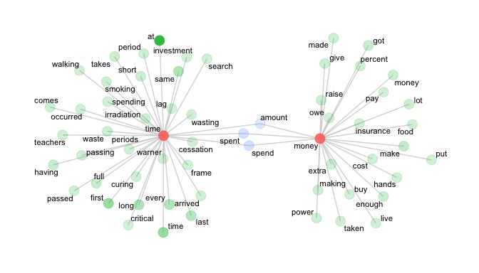

```r
ggraph(net, weight = link_weight, layout = "stress") +
  geom_edge_link(color = "gray80", alpha = .75) +
  geom_node_point(aes(alpha = node_weight, size = 3, color = n_intersects)) +
  geom_node_text(aes(label = label), repel = T, size = 3) +
  scale_alpha(range = c(0.2, 0.9)) +
  theme_graph() +
  theme(legend.position="none")
```

## Bibliography

Brezina, Vaclav. 2018. “Collocation Graphs and Networks: Selected Applications.” In *Lexical Collocation Analysis*, 59–83. Springer. https://link.springer.com/chapter/10.1007/978-3-319-92582-0_4.

Brezina, Vaclav, Tony McEnery, and Stephen Wattam. 2015. “Collocations in Context: A New Perspective on Collocation Networks.” *International Journal of Corpus Linguistics* 20 (2): 139–73. https://www.jbe-platform.com/content/journals/10.1075/ijcl.20.2.01bre.

Church, Kenneth, and Patrick Hanks. 1990. “Word Association Norms, Mutual Information, and Lexicography.” *Computational Linguistics* 16 (1): 22–29. https://aclanthology.org/J90-1003.pdf.